# Coursework Report

*N* removed NAs: 3

*N* removed typo: 1

*N* removed <18: 25

*N* total clean: 121

| Group | *N* | *M*<sub>age</sub> | *M*<sub>rating</sub> |
| --- | --- | --- | --- |
| Control | 64 | 21.33 | 5.45 |
| Experim | 57 | 21.19 | 6.39 |

**Main analysis results**

*t*(119) = -6.7, *p* < .001

[interactive chart not shown]

[figure not shown]

[interactive chart not shown]

# Coursework Report

Analysing Data, Spring 2020

# Methods

## Participants

In this study, data was collected from 121 pariticpants, with a mean age of 21 years. The overall standard deviation for age was 2.21, with a range of ages between 18 years old and 27 years old. Participants data who’s ages were below 18, were removed from the data set, to elminate the possibility of using data from minors.

Table 1 *Desciptive Statistics by Age*

| Condition | *M*<sub>age</sub> | *SD*<sub>age</sub> | *Min*<sub>age</sub> | *Max*<sub>age</sub> |
| --- | --- | --- | --- | --- |
| control | 21.33 | 2.08 | 18 | 26 |
| experimental | 21.19 | 2.37 | 18 | 27 |

## Design

This study used an independent measures design where participants were divided into the control and experimental condition. The conceptual hypothesis for this study seeks to understand whether colour, infuences a women’s attraction towards men.

The independent variable was the background colour of which the photo of the man is presented, i.e. white (control condition) or red (experimental condition). The dependent variable was how women perceived attractiveness, this was measured by having the participants answering 3 questions using a 9-point rating scale, an average was taken from these answers and a compisite score was then obtained.

Therefore, the operationalised hypothesis for this study is that, when a picture of a man is displayed in a red coloured frame, mean ratings of attractviness will be higher.

# Results

We investigated whether participants would give a higher attractive rating when shown a picture of a male in a red background compared to a male pictured in a white background.

Using an independent-measures *t*-test, the analysis showed that, as predicted, males that were pictured in a red background (experimental) were given a higher mean rating of attraction (*M* = 6.39), than a male pictured in a white background (control) (*M* = 5.45), this is shown in Figure 1.

Composite scores were obtained by finding the mean attraction rating for all 3 questions from each participant.

The results from the *t*-test show that there is a significant difference between the experimental and control condition, (*M*<sub>diff</sub> = -0.93, 95% CI [-1.21, -0.66], *t* (119) = -6.7, *p*< 0.05.

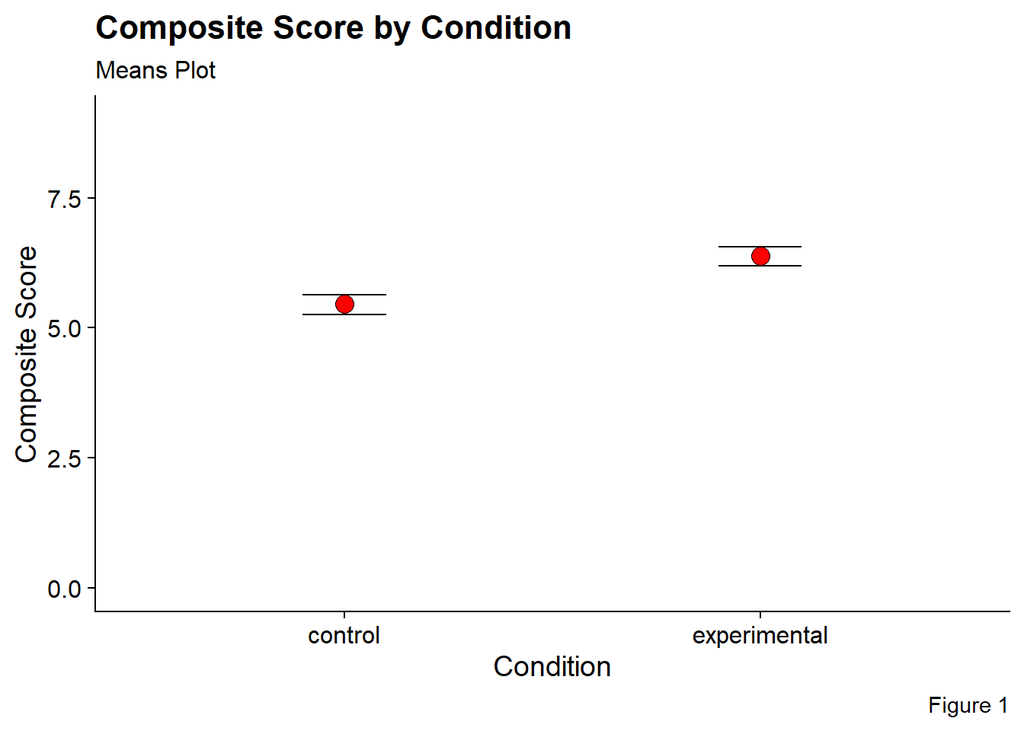

# Discussion

The main finding of this study shows that participants in the experimental condition, who viewed a picture of a male against a red background, gave higher mean attractive ratings, compared to the participants in the control condition, who viewed a picture of a male against a white background. This suggests that the original hypothesis was correct in assuming that there is a relationship between the colour red and attractive ratings, where participants will rate men as more attractive, when displayed against the colour red.

This research therefore supports the findings of the original study by Elliot et al., (2010), in which their results indicated that females rated the male figure in a red frame, as more attractive than the male in the white frame. As both the replication and original study (Elliot et al., 2010), supports the idea of the “red effect” (such as, the colour red making men seem “more attractive and sexually desirable”, Elliot et al., 2010, p.400), it may be assumed that the findings are reproducible. This implies that the present data, has a higher chance of being concurrently valid.

Studies that have also been interested in the relationship between the colour red and attraction, have found similar evidence that colour does have an influence on sexual desirability or attraction. Elliot and Niesta (2008) analysed the red effect on males attraction to females. Their results showed that even just a small glimpse of red, increased males attraction towards females. This highlights that the influence of the colour red in connection to attraction, may not just be limited to one gender.

However, not all replications of Elliot et al.’s (2010) study give desirable results, where the colour red is found to enhance attraciton. Hesslinger, Goldbach and Carbon (2015), replicated the first experiment from Elliot et al.’s (2010) study and found no significant difference between the mean attraction ratings from participants who had viewed the male on a red background, compared to mean attraction ratings from participants who had viewed the male on a white background. Hesslinger et al., (2015) suggests that the inconsistency of results may be due to a lack of ecological validity, and that there are other factors to take into consideration for example, clothing style. Lehmann, Elliot and Calin-Jageman (2018), conducted a meta-analysis on the red effect and attraction and concluded that this effect is essentially non-existent and when it does occur, it is very small. Therefore, future research should take in to consideration other factors that may have an impact on attraction to see whether colour, plus an additional variable, affects ratings of attraction in the same way.

Furthermore, the results from the present study and other replications mentioned, were done in a laboratory setting, and therefore cannot be generalised to opinions of attraction that are taken in a more naturalistic environment (Hesslinger et al., 2015). Therefore, it will be important for future research to incorporate this within their studies, so that results can be applied to real-life scenarios; for example, using a face-to-face dating scenario where colour is manipulated.

The sample size of the present study was much larger than Elliot et al.’s (2010) original study, this allows for more accurate mean scores and increases the generalisability of the results. However, unlike in Elliot and Niesta (2008), there is no explanation as to why the colour red may influence ratings of attraction. Therefore in future studies, this may be a useful focal point so that important implications can be established.

In conclusion, this replication of Elliot et al.’s (2010) study, did support the findings that the colour red does have a part to play in influencing people’s ratings of attraction. However, one must take in to consideration that not all replications have obtained the same result and thus other factors must be investigated in future research, for example clothing attire or environment (Hesslinger et al., 2015). It is also important to test this effect in different environments to understand whether natural situations produce the same results. Overall, from the present study we can conclude with caution that, the colour red does affect ratings of attraction.

# References

Elliot, A. J., Niesta Kayser, D., Greitemeyer, T., Lichtenfeld, S., Gramzow, R. H., Maier, M. A., & Liu, H. (2010). Red, rank, and romance in women viewing men. *Journal of Experimental Psychology: General*, *139*(3), 399-417. doi:http://dx.doi.org/10.1037/a0019689

Elliot, A. J., & Niesta, D. (2008). Romantic red: Red enhances men’s attraction to women. *Journal of Personality and Social Psychology, 95*(5), 1150-1164. doi:http://dx.doi.org/10.1037/0022-3514.95.5.1150

Hesslinger, V.M., Goldbach, L. & Carbon, C (2015). Men in red: A reexamination of the red-attractiveness effect. *Psychon Bull Rev*,(22), 1142–1148. https://doi.org/10.3758/s13423-015-0866-8

Lehmann, G. K., Elliot, A. J., & Calin-Jageman, R. J. (2018). Meta-Analysis of the Effect of Red on Perceived Attractiveness. *Evolutionary Psychology*. https://doi.org/10.1177/1474704918802412